# 통계 방법론Ⅱ - 탐색적 데이터 분석

응용통계학과 이준혁

2023-06-10(토)

# Ch8. 저항선과 강건 회귀(Resistance Line & Robust Regression)

## 8.1. 저항선 Resistance Line

- 3-요약점(3-summary point)과 잔차(residuals)를 이용한 반복 적합과 교정을 통하여 이상점들의 영향을 덜 받는 직선식을 추정하는 방법이다.
- 회귀 분석이 평균으로 계산하니까 이상점에 민감하다.
  - 이를 극복하기 위한 방법 중 하나이다.

### 8.1.1. diamonds 중에서 일부 데이터(jset.csv)

#### 8.1.1.1. 데이터 불러오기

```r
jset <- read.csv(paste0(data_path, "jset.csv"))
```

#### 8.1.1.2. 데이터 구조 확인

```r
na_count(jset)
```

```
##   carat     cut   color clarity   depth   table   price       x       y       z
##       0       0       0       0       0       0       0       0       0       0
## s.price
##       0
```

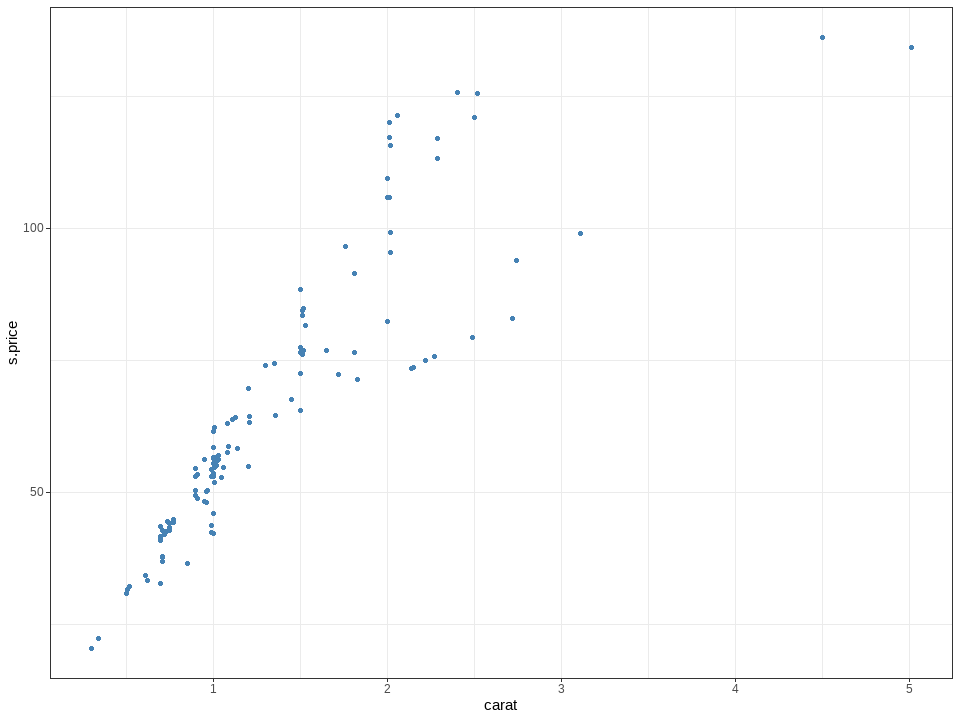

```r
jset %>%
  ggplot(aes(carat, s.price)) +
  geom_point(color = sbl) +
  theme_bw()
```

#### 8.1.1.3. 저항선의 적합(1차)

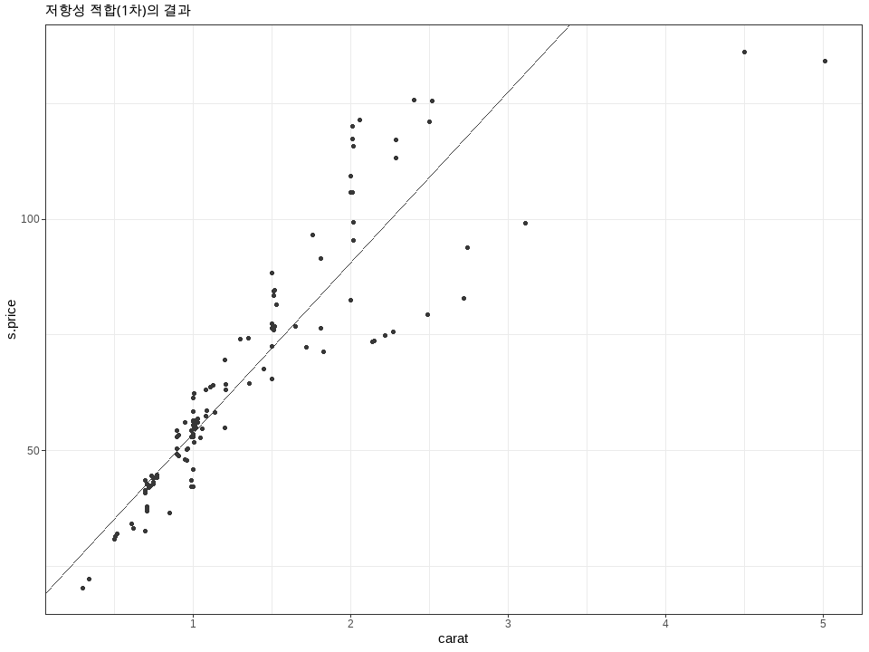

```r
first <- rline(s.price ~ carat, jset, iter = 1)

jset %>%
  ggplot(aes(carat, s.price)) +
  geom_point(color = "#383838") +
  geom_abline(intercept = first$a - first$b * first$xC,
              slope = first$b,
              color = ldg
              ) +
  labs(subtitle = "저항성 적합(1차)의 결과") +
  theme_bw()
```

#### 8.1.1.4. 저항선의 반복 적합

```r
#초기화
out <- data.frame(Iteration = NULL, Slope = NULL, Intercept = NULL)
iter.limit <- 10
#반복
for(iterations in 1:iter.limit){
  rfit <- rline(s.price ~ carat, jset, iter = iterations)
  out <- rbind(out,
               data.frame(Iteration = iterations,
                          Slope = rfit$b,
                          Intercept = rfit$a)
  )
}
#결과
out
```

```
##    Iteration    Slope Intercept
## 1          1 36.94209  54.97521
## 2          2 43.29758  55.50847
## 3          3 44.63215  55.66989
## 4          4 44.65560  55.62380
## 5          5 44.65532  55.62367
## 6          6 44.65532  55.62368
## 7          7 44.65532  55.62368
## 8          8 44.65532  55.62368
## 9          9 44.65532  55.62368
## 10        10 44.65532  55.62368
```

#### 8.1.1.5. iter = 6

- 6번째 반복 이후의 **절편(55.62368)**, **기울기(44.65532)**로 수렴한다.
  - 따라서, iter = 6으로 최종 저항선을 추정한다.

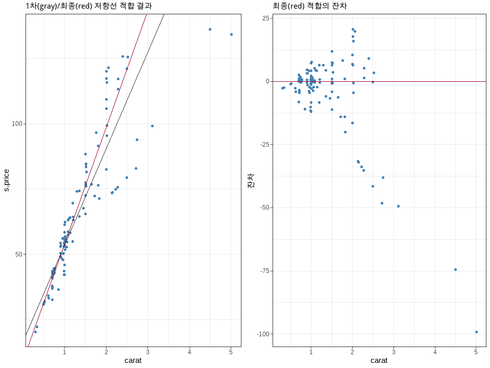

```r
final <- rline(s.price ~ carat, jset, iter = 6)
jset$res <- final$residual
#
j1 <- jset %>%
  ggplot(aes(carat, s.price)) +
  geom_point(color = sbl) +
  geom_abline(intercept = first$a - first$b*first$xC,
              slope = first$b,
              color = ldg) +
  geom_abline(intercept = final$a - final$b*final$xC,
              slope = final$b,
              color = lre) +
  labs(subtitle = "1차(gray)/최종(red) 저항선 적합 결과") +
  theme_bw()

j2 <- jset %>%
  ggplot(aes(carat, res)) +
  geom_point(color = sbl) +
  geom_hline(yintercept = 0,
             color = lre) +
  labs(subtitle = "최종(red) 적합의 잔차", y = "잔차") +
  theme_bw()

grid.arrange(j1, j2, ncol = 2)
```

```r
jset %>%
  dplyr::filter(res <= -25) %>%
    dplyr::select(clarity, carat, table, s.price)
```

```
##    clarity carat table   s.price
## 1       I1  2.14    57  73.51871
## 2       I1  2.15    57  73.68853
## 3       I1  2.22    56  74.87990
## 4       I1  2.27    55  75.71658
## 5       I1  2.49    58  79.30322
## 6       I1  2.72    56  82.88546
## 7       I1  2.74    61  93.84562
## 8       I1  3.11    57  99.11105
## 9       I1  5.01    59 134.23114
## 10      I1  4.50    58 136.12862
```

## 8.2 강건 선형 회귀 Robust Linear Regression

- 선형 회귀 분석은 오차에 가정되는 확률 분포의 타당성 여부와 이상점의 영향을 많이 받는다는 단점을 갖는다.
  - 이러한 단점을 보완할 수 있는 방법으로 다음의 강건(rubust) 선형 회귀 분석이 소개되었다.
    - 최소 중앙값 제곱
    - 최소 절사 제곱
    - 후버의 M추정

### 8.2.1. simple 데이터 실습(simple.csv)

```r
#데이터 로드
simple <- read_csv(paste0(data_path, "simple.csv"),show_col_types = FALSE)
str(simple)
```

```
## spc_tbl_ [13 × 2] (S3: spec_tbl_df/tbl_df/tbl/data.frame)
##  $ x: num [1:13] 0.7 1.1 1.2 1.7 2 2.1 2.1 2.5 1.6 3 ...
##  $ y: num [1:13] 0.5 0.6 1 1.6 0.9 1.6 1.5 2 2.1 2.5 ...
##  - attr(*, "spec")=
##   .. cols(
##   ..   x = col_double(),
##   ..   y = col_double()
##   .. )
##  - attr(*, "problems")=<externalptr>
```

```r
#결측값 개수 확인
sum(is.na(simple))
```

```
## [1] 0
```

```r
na_count(simple)
```

```
## x y
## 0 0
```

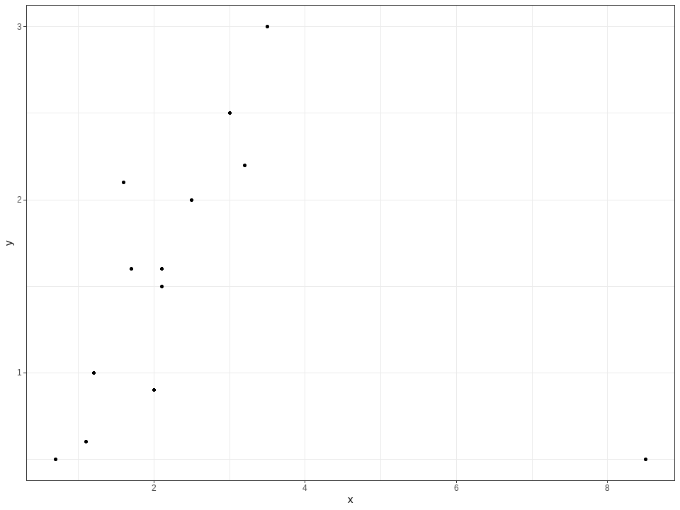

```r
#산점도로 데이터 파악
simple %>%
  ggplot(aes(x = x, y = y)) +
  geom_point(color = "black") +
  theme_bw()
```

- 단순 회귀 분석 적합

```r
fit.lin <- lm(y ~ x, simple)
summary(fit.lin)
```

```
##
## Call:
## lm(formula = y ~ x, data = simple)
##
## Residuals:
##      Min       1Q   Median       3Q      Max
## -1.04590 -0.64068  0.05811  0.55771  1.46533
##
## Coefficients:
##             Estimate Std. Error t value Pr(>|t|)
## (Intercept)  1.54870    0.39137   3.957  0.00225 **
## x           -0.00401    0.12310  -0.033  0.97460
## ---
## Signif. codes:  0 '***' 0.001 '**' 0.01 '*' 0.05 '.' 0.1 ' ' 1
##
## Residual standard error: 0.8405 on 11 degrees of freedom
## Multiple R-squared:  9.646e-05,  Adjusted R-squared:  -0.0908
## F-statistic: 0.001061 on 1 and 11 DF,  p-value: 0.9746
```

- 다항 회귀 분석 적합

```r
fit.poly <- lm(y ~ x + I(x^2), simple)
summary(fit.poly)
```

```
##
## Call:
## lm(formula = y ~ x + I(x^2), data = simple)
##
## Residuals:
##     Min      1Q  Median      3Q     Max
## -0.7812 -0.2284 -0.0243  0.1659  0.7646
##
## Coefficients:
##             Estimate Std. Error t value Pr(>|t|)
## (Intercept) -0.53106    0.39445  -1.346 0.207921
## x            1.40827    0.24200   5.819 0.000168 ***
## I(x^2)      -0.15107    0.02508  -6.024 0.000128 ***
## ---
## Signif. codes:  0 '***' 0.001 '**' 0.01 '*' 0.05 '.' 0.1 ' ' 1
##
## Residual standard error: 0.4097 on 10 degrees of freedom
## Multiple R-squared:  0.784,  Adjusted R-squared:  0.7408
## F-statistic: 18.15 on 2 and 10 DF,  p-value: 0.0004703
```

- 산점도 비교(단순회귀분석 Vs 다항회귀분석) - 단순 회귀 모형은 데이터의 패턴을 찾지 못한다. - 다항 회귀 식은 오른쪽에 위치한 이상치에 민감하게 반응한다.

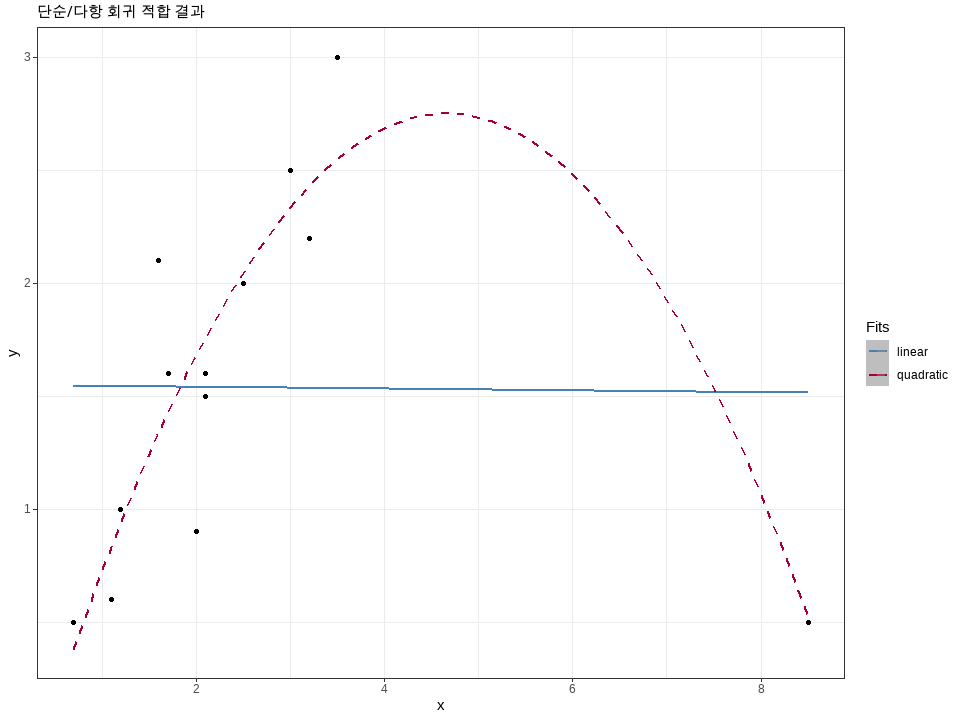

```r
colors <- c("linear" = sbl, "quadratic" = lre)
simple %>%
  ggplot(aes(x = x, y = y)) +
  geom_point(color = "black") +
  stat_smooth(aes(x, fit.lin$fitted.values, color = "linear")) +
  stat_smooth(aes(x, fit.poly$fitted.values, color = "quadratic"), linetype="dashed") +
  labs(color = "Fits", subtitle = "단순/다항 회귀 적합 결과") +
  theme_bw() +
  scale_color_manual(values = colors)
```

- 최소 중앙값 제곱(LMS, Least Median of Squares) 적용하기
  - R의 `MASS` 패키지 내에 있는 **lqs(method = “lms”)**

```r
lms <- MASS::lqs(y ~ x, method = "lms", data = simple)
lms
```

```
## Call:
## lqs.formula(formula = y ~ x, data = simple, method = "lms")
##
## Coefficients:
## (Intercept)            x
##     -0.2536       0.8929
##
## Scale estimates 0.1746 0.2178
```

- 산점도 비교

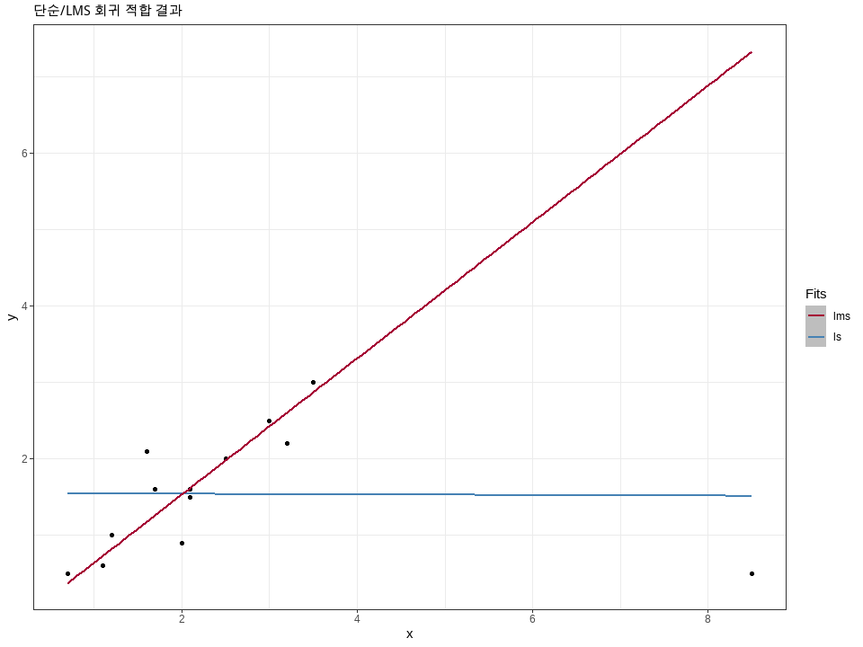

```r
colors <- c("ls" = sbl, "lms" = lre)
simple %>%
  ggplot(aes(x = x, y = y)) +
  geom_point(color = "black") +
  stat_smooth(aes(x, fit.lin$fitted.values, color = "ls")) +
  stat_smooth(aes(x, lms$fitted.values, color = "lms")) +
  labs(color = "Fits", subtitle = "단순/LMS 회귀 적합 결과") +
  theme_bw() +
  scale_color_manual(values = colors)
```

- 최소 절사 제곱(LTS, Least Trimmed Squares)은 R의의 `MASS` 패키지 내에 있는 **lqs(method = “lts”)** 함수

```r
lts <- MASS::lqs(y ~ x, method = "lts", data = simple)
lts
```

```
## Call:
## lqs.formula(formula = y ~ x, data = simple, method = "lts")
##
## Coefficients:
## (Intercept)            x
##     -0.1472       0.8696
##
## Scale estimates 0.2322 0.2148
```

- 단순/LMS/LTS 회귀 적합 결과 산점도 비교

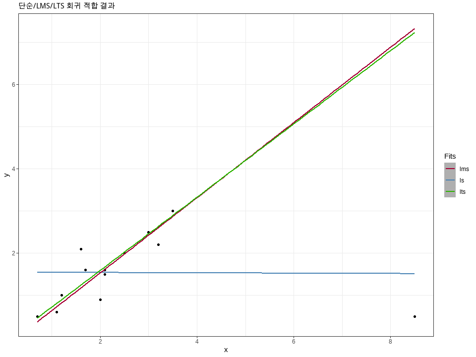

```r
colors <- c("ls" = sbl, "lms" = lre, "lts" = ngr)
simple %>%
  ggplot(aes(x = x, y = y)) +
  geom_point(color = "black") +
  stat_smooth(aes(x, fit.lin$fitted.values, color = "ls")) +
  stat_smooth(aes(x, lms$fitted.values, color = "lms")) +
  stat_smooth(aes(x, lts$fitted.values, color = "lts")) +
  labs(color = "Fits", subtitle = "단순/LMS/LTS 회귀 적합 결과") +
  theme_bw() +
  scale_color_manual(values = colors)
```

### 8.2.2. phonecall 데이터(phonecall.csv)

- 후버의 M 추정 - M-estimation은 R의의 `MASS` 패키지 내에 있는 **rlm(psi = psi.huber)** 함수

```r
#데이터 로드
phonecall <- read_csv(paste0(data_path, "phonecall.csv"),show_col_types = FALSE)
str(phonecall) #2개 변수
```

```
## spc_tbl_ [24 × 2] (S3: spec_tbl_df/tbl_df/tbl/data.frame)
##  $ year : num [1:24] 50 51 52 53 54 55 56 57 58 59 ...
##  $ calls: num [1:24] 0.44 0.47 0.47 0.59 0.66 0.73 0.81 0.88 1.06 1.2 ...
##  - attr(*, "spec")=
##   .. cols(
##   ..   year = col_double(),
##   ..   calls = col_double()
##   .. )
##  - attr(*, "problems")=<externalptr>
```

```r
#결측값 개수 확인
sum(is.na(phonecall))
```

```
## [1] 0
```

```r
na_count(phonecall)
```

```
##  year calls
##     0     0
```

```r
rlm <- MASS::rlm(calls ~ year, phonecall, psi = psi.huber, maxit = 50)
rlm
```

```
## Call:
## rlm(formula = calls ~ year, data = phonecall, psi = psi.huber,
##     maxit = 50)
## Converged in 33 iterations
##
## Coefficients:
## (Intercept)        year
##  -10.262220    0.204135
##
## Degrees of freedom: 24 total; 22 residual
## Scale estimate: 0.903
```

- 단순/LMS/LTS/RLM 회귀 적합 결과 산점도 비교

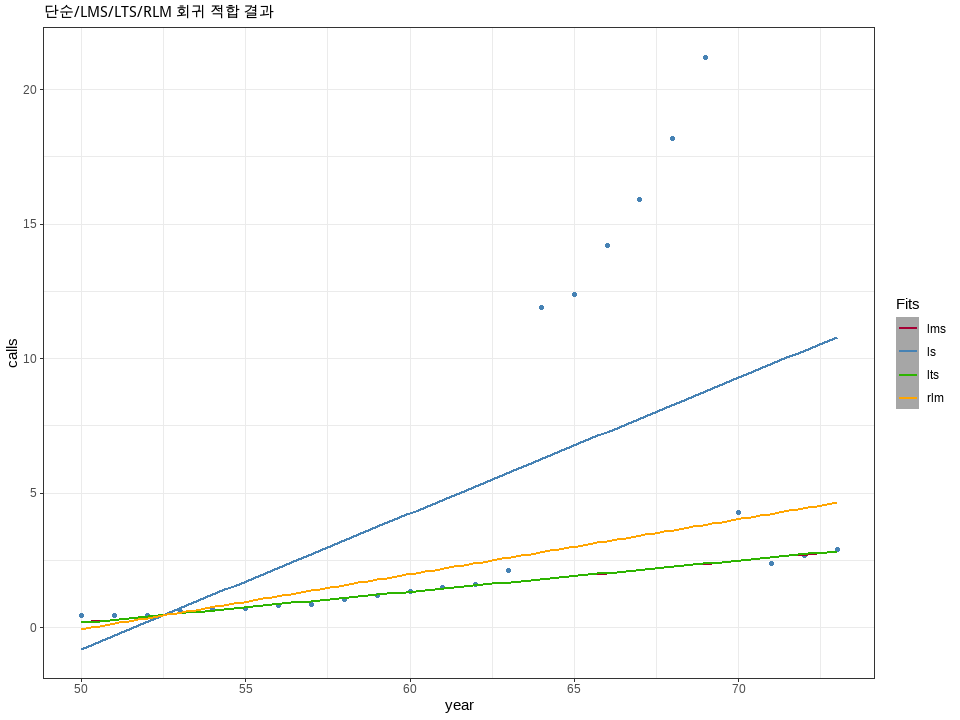

```r
lin <- lm(calls ~ year, phonecall)
plms <- MASS::lqs(calls ~ year, method = "lms", data = phonecall)
plts <- MASS::lqs(calls ~ year, method = "lts", data = phonecall)

colors <- c("ls" = sbl, "lms" = lre, "lts" = ngr, "rlm" = "orange")
phonecall %>%
  ggplot(aes(x = year, y = calls)) +
  geom_point(color = sbl) +
  stat_smooth(aes(year, lin$fitted.values, color = "ls")) +
  stat_smooth(aes(year, plms$fitted.values, color = "lms")) +
  stat_smooth(aes(year, plts$fitted.values, color = "lts")) +
  stat_smooth(aes(year, rlm$fitted.values, color = "rlm")) +
  labs(color = "Fits", subtitle = "단순/LMS/LTS/RLM 회귀 적합 결과") +
  theme_bw() +
  scale_color_manual(values = colors)
```

### 8.2.3. diamonds 데이터

```r
#데이터로드
data(diamonds)
jset <- diamonds %>%
  dplyr::filter(color == "J") %>%
  dplyr::filter(cut == "Fair")
str(jset)
```

```
## tibble [119 × 10] (S3: tbl_df/tbl/data.frame)
##  $ carat  : num [1:119] 1.05 1 0.99 0.9 0.91 0.91 1 0.99 0.9 0.9 ...
##  $ cut    : Ord.factor w/ 5 levels "Fair"<"Good"<..: 1 1 1 1 1 1 1 1 1 1 ...
##  $ color  : Ord.factor w/ 7 levels "D"<"E"<"F"<"G"<..: 7 7 7 7 7 7 7 7 7 7 ...
##  $ clarity: Ord.factor w/ 8 levels "I1"<"SI2"<"SI1"<..: 2 4 3 4 4 4 5 3 5 5 ...
##  $ depth  : num [1:119] 65.8 65.7 55 65 64.4 65.4 65.5 58 65.4 64.6 ...
##  $ table  : num [1:119] 59 59 61 56 62 60 55 67 60 58 ...
##  $ price  : int [1:119] 2789 2811 2812 2815 2854 2854 2875 2949 2964 2964 ...
##  $ x      : num [1:119] 6.41 6.14 6.72 6.08 6.06 6.04 6.3 6.57 6.02 6.12 ...
##  $ y      : num [1:119] 6.27 6.07 6.67 6.04 6.03 6 6.25 6.5 5.93 6.06 ...
##  $ z      : num [1:119] 4.18 4.01 3.68 3.94 3.89 3.94 4.11 3.79 3.91 3.93 ...
```

```r
set <- jset %>%
  mutate(s.price = sqrt(price))
```

- 산점도 파악

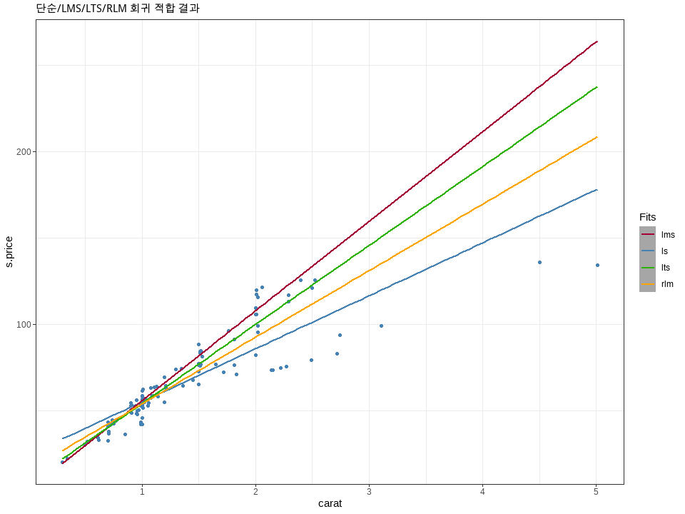

```r
colors <- c("ls" = sbl, "lms" = lre, "lts" = ngr, "rlm" = "orange")
set$lin <- lm(s.price ~ carat, set)$fitted.value
set$rlm <- rlm(s.price ~ carat, set, psi = psi.huber, maxit = 50)$fitted.value
set$lms <- lqs(s.price ~ carat, method = "lms", data = set)$fitted.value
set$lts <- lqs(s.price ~ carat, method = "lts", data = set)$fitted.value

set %>%
  ggplot(aes(x = carat, y = s.price)) +
  geom_point(color = sbl) +
  stat_smooth(aes(carat, lin, color = "ls")) +
  stat_smooth(aes(carat, lms, color = "lms")) +
  stat_smooth(aes(carat, lts, color = "lts")) +
  stat_smooth(aes(carat, rlm, color = "rlm")) +
  labs(color = "Fits", subtitle = "단순/LMS/LTS/RLM 회귀 적합 결과") +
  theme_bw() +
  scale_color_manual(values = colors)
```

## 8.3 스플라인스 선형 회귀 Splines Linear Regression

- 설명 변수의 범위 별로 서로 다른 함수적 관계가 존재하는 경우, 적절한 범위를 구분하여 너트(knot)를 정의하고 이 모형을 고려할 수 있다.

### qmr 데이터(qmr.csv)

- 00전자의 SW사업부에서의 QM 검증 결과의 타당성을 확인하고 QMR Score와의 관계를 분석하기 위하여 24개의 제품(자사, 경쟁사)을 조사하였다. 적절한 모형이 도출된다면, 이를 이용하여 SW 초기 완성도 판단을 위한 검토 기준으로 활용하고자 한다.

```r
#데이터 로드
qm <- read_csv(paste0(data_path, "qmr.csv"), show_col_types = FALSE)
str(qm)
```

```
## spc_tbl_ [24 × 3] (S3: spec_tbl_df/tbl_df/tbl/data.frame)
##  $ QR.Score : num [1:24] 15.8 21.1 26.3 36.8 52.6 52.6 57.9 68.4 78.9 84.2 ...
##  $ QMR.Score: num [1:24] 1.61 1.96 2.11 2.5 3.95 4.04 4.13 4.11 4.32 4.32 ...
##  $ Maker    : chr [1:24] "B" "B" "B" "B" ...
##  - attr(*, "spec")=
##   .. cols(
##   ..   QR.Score = col_double(),
##   ..   QMR.Score = col_double(),
##   ..   Maker = col_character()
##   .. )
##  - attr(*, "problems")=<externalptr>
```

```r
#결측값 개수 확인
sum(is.na(qm))
```

```
## [1] 0
```

```r
na_count(qm)
```

```
##  QR.Score QMR.Score     Maker
##         0         0         0
```

```r
#데이터 구조 변경 - 변수명
qm <- qm %>% dplyr::rename_all(tolower) %>% #소문자로 변경
  dplyr::rename(qmr = qmr.score, qr = qr.score) %>%
  dplyr::relocate(qmr)
qm
```

```
## # A tibble: 24 × 3
##      qmr    qr maker
##    <dbl> <dbl> <chr>
##  1  1.61  15.8 B
##  2  1.96  21.1 B
##  3  2.11  26.3 B
##  4  2.5   36.8 B
##  5  3.95  52.6 B
##  6  4.04  52.6 B
##  7  4.13  57.9 B
##  8  4.11  68.4 B
##  9  4.32  78.9 B
## 10  4.32  84.2 B
## # ℹ 14 more rows
```

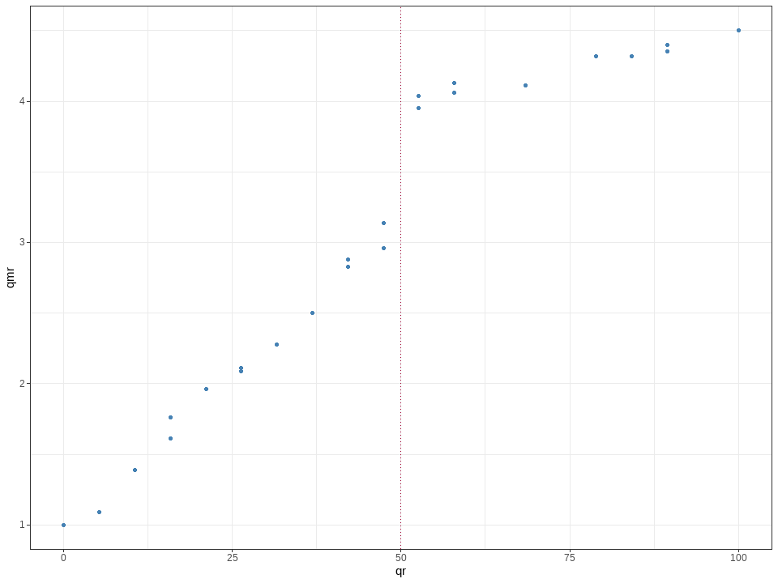

```r
#관계 패턴 확인
qm %>%
  ggplot(aes(x = qr, y = qmr)) +
  geom_point(color = sbl) +
  geom_vline(xintercept = 50, color = lre, linetype = "dotted") +
  theme_bw()
```

```r
#너트(knot) 정의
qm <- qm %>%
  mutate(knot1 = ifelse(qr - 50 > 0, (qr - 50), 0),
         knot0 = ifelse(qr- 50 > 0 , 1, 0))
qm
```

```
## # A tibble: 24 × 5
##      qmr    qr maker knot1 knot0
##    <dbl> <dbl> <chr> <dbl> <dbl>
##  1  1.61  15.8 B       0       0
##  2  1.96  21.1 B       0       0
##  3  2.11  26.3 B       0       0
##  4  2.5   36.8 B       0       0
##  5  3.95  52.6 B       2.6     1
##  6  4.04  52.6 B       2.6     1
##  7  4.13  57.9 B       7.9     1
##  8  4.11  68.4 B      18.4     1
##  9  4.32  78.9 B      28.9     1
## 10  4.32  84.2 B      34.2     1
## # ℹ 14 more rows
```

- 스플라인스 회귀 적합

```r
lin_fit <- lm(qmr ~ qr + knot0 + knot1, data = qm)
summary(lin_fit)
```

```
##
## Call:
## lm(formula = qmr ~ qr + knot0 + knot1, data = qm)
##
## Residuals:
##       Min        1Q    Median        3Q       Max
## -0.093013 -0.043472 -0.003254  0.045663  0.111826
##
## Coefficients:
##              Estimate Std. Error t value Pr(>|t|)
## (Intercept)  0.948217   0.034126   27.79  < 2e-16 ***
## qr           0.044301   0.001126   39.34  < 2e-16 ***
## knot0        0.819693   0.046689   17.56 1.28e-13 ***
## knot1       -0.034148   0.001652  -20.68 5.72e-15 ***
## ---
## Signif. codes:  0 '***' 0.001 '**' 0.01 '*' 0.05 '.' 0.1 ' ' 1
##
## Residual standard error: 0.06328 on 20 degrees of freedom
## Multiple R-squared:  0.9975, Adjusted R-squared:  0.9972
## F-statistic:  2688 on 3 and 20 DF,  p-value: < 2.2e-16
```

- 스플라인스 회귀 추정 결과 및 잔차의 확인

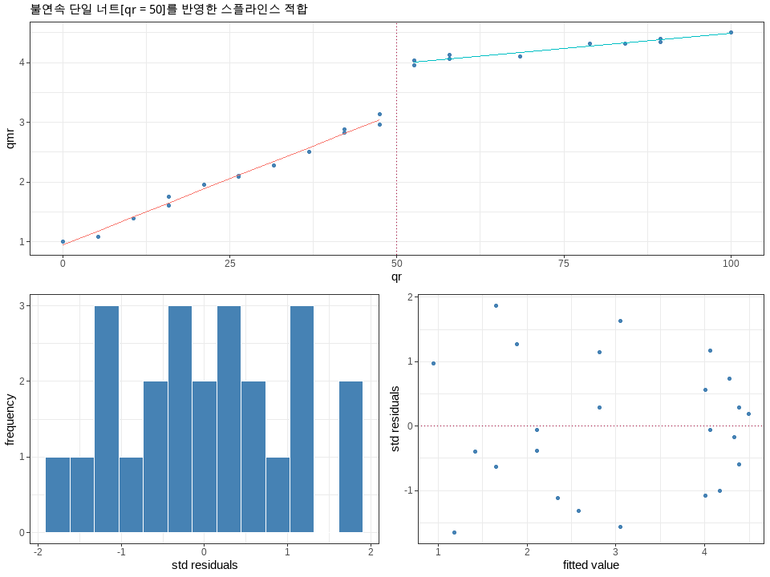

```r
qm$fit <- fitted(lin_fit)

q1 <- qm %>%
  ggplot(aes(x = qr, y = qmr, color = as.factor(knot0)),
         show.legend = FALSE
         ) +
  geom_point(color = sbl) +
  geom_vline(xintercept = 50,
             color = lre,
             linetype = "dotted"
             ) +
  geom_line(aes(x = qr, y = fit, color = as.factor(knot0)),
            show.legend = FALSE
            ) +
  labs(subtitle = "불연속 단일 너트[qr = 50]를 반영한 스플라인스 적합") +
  theme(legend.position = "none") +
  theme_bw()

q2 <- lin_fit %>%
  ggplot(aes(rstandard(lin_fit))) +
  geom_histogram(bins = 13, color = "white", fill = sbl) +
  labs(x = "std residuals", y = "frequency") +
  theme_bw()

q3 <-lin_fit %>%
  ggplot(aes(fitted(lin_fit), rstandard(lin_fit))) +
  geom_point(color = sbl) +
  geom_hline(yintercept = 0,
             color = lre,
             linetype = "dotted"
             ) +
  labs(x = "fitted value", y = "std residuals") +
  theme_bw()

gridExtra::grid.arrange(q1, gridExtra::arrangeGrob(q2, q3, ncol = 2),
                        nrow = 2)
```